# My visual data story showing the affects differences in scrolling habbits depending on time of day and social media app of choice.

## How does our social media apps affect how long we scroll?

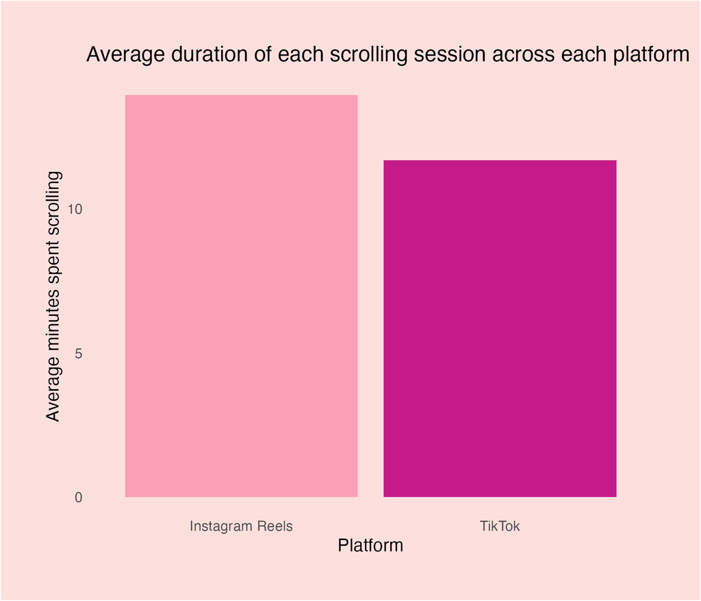

Here I wanted to look into whether some social media apps caused me to scroll for longer on average. Looking at the average time spent scrolling across each app it looks like they are very similar. This may indicate that the app itself does not have much of an impact on how long a person will scroll for, and maybe this is instead dependent on other external factors instead.

## What does the distribution of scrolling lengths look like and does this depend on the time of day?

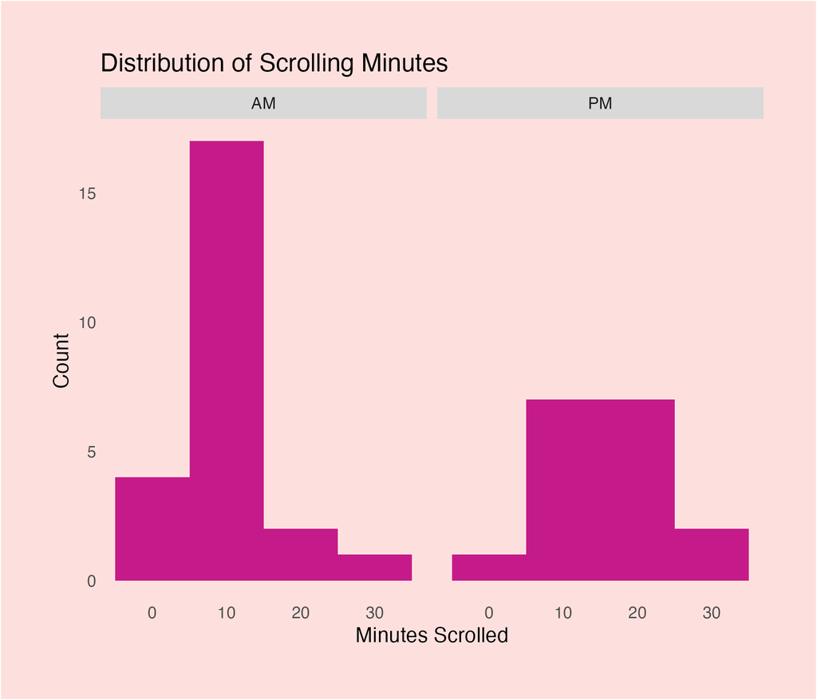

Here I was interested in analysing if there was a certain range of time spent scrolling, e.g. around 15 minutes, which was more common than other times, and if this changed depending on if it was morning or afternoon. Looking at this plot revealed that there was in fact more occurances of me scrolling for around 10 minutes in the morning than any other time of day. There was also less observations of scrolling for around 20 and 30 minutes in the morning versus the afternoon, which may indicate that I have less free time in the mornings compared to afternoons, and thus spend less time on social media.

## How does this change on an hourly basis?

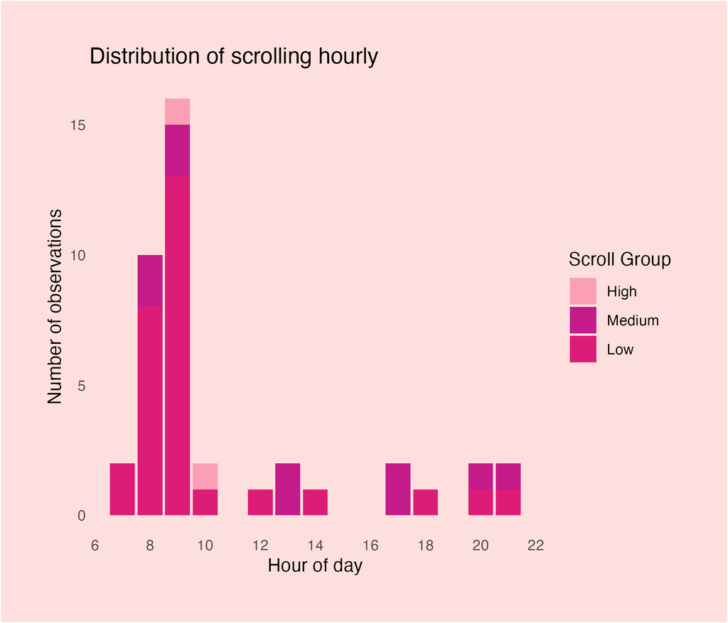

Here I wanted to further investigate the distribution of scrolling, but by occurances rather than minutes. This shows me that around 8 and 9 in the morning was when the vast majority of my responses were recorded. This this was based on the google forum submission, rather than the time of day I was scrolling. As I did not always submit the form right after using social media, it is skewed by the time of day I was working on my project, because that is when I would record a lot of the times I had scrolled recently. As such I can’t draw any concrete conclusions using this graph, however it does show a few small observations of medium scrolling lengths (15-30 minutes) around 1pm and 5pm which might indicate social media usage with lunch and dinner